# Unit3DDSAssignment

Blaine Brewer

January 27, 2019

## Questions

#### 1. GitHub Cloning (20 points): Using Git, clone the following GitHub repository to your local machine: https://github.com/caesar0301/awesome-public-datasets. In RMarkdown, please show the code (commented out, as it’s not R syntax) that you used to create a new directory, navigate to the appropriate directory, and clone the repository to it. One Git command per line, please.

```r
## ls
## mkdir GIT
## ls
## cd GIT
## git clone "https://github.com/caesar0301/awesome-public-datasets"
```

#### 2. Data Summary (20 points): From this aforementioned cloned repo, please extract titanic.csv.zip. To be clear, this does not have to be done in Git or command line.

##### a. In R, please read in titanic.csv via either read.table() or read.csv(), assigning it to df. This dataset follows the passengers aboard the Titanic, including their fees paid, rooms rented, and survivorship status.

```r
df <- read.csv("GIT/awesome-public-datasets/Datasets/titanic.csv")
```

##### b. Output the respective count of females and males aboard the Titanic. Plot the frequency of females and males. Be sure to give an accurate title and label the axes.

```r
kable(table(df$Sex))
```

| Var1 | Freq |
| --- | --- |
| female | 314 |
| male | 577 |

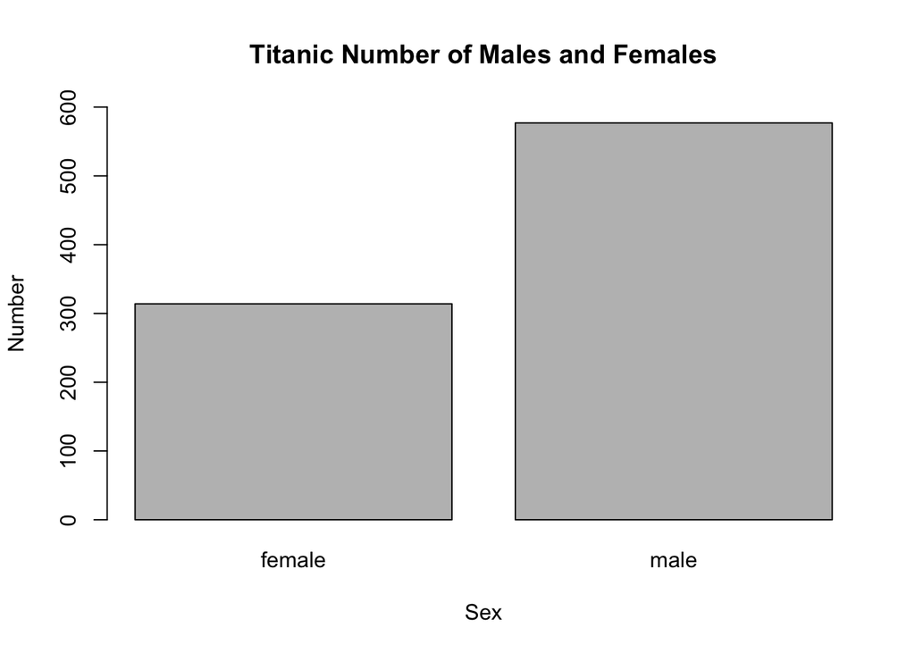

```r
maxVal <- max(table(df$Sex))
lenVal <- nchar(maxVal)
yMax <- round(maxVal, -(lenVal-1))
plot(df$Sex, ylim=c(0,yMax), ylab="Number", xlab="Sex", main="Titanic Number of Males and Females")
```

##### c. Please use one apply function (to review: swirl() modules 11, 12) to output the means of Age, Fare, and Survival. Make sure the output is a real number for all three means.

```r
mean.df <- df[,c("Survived","Age","Fare")]
mean.df$Survived <- as.numeric(mean.df$Survived)
means <- sapply(mean.df, mean, na.rm=TRUE)
as.data.frame(means)
```

```
##               means
## Survived  0.3838384
## Age      29.6991176
## Fare     32.2042080
```

```r
kable(as.data.frame(means), caption = "A table of means of Survived, Age, and Fare.")
```

A table of means of Survived, Age, and Fare.

|  | means |
| --- | --- |
| Survived | 0.3838384 |
| Age | 29.6991176 |
| Fare | 32.2042080 |

#### 3. Function Building (30 points): You research sleep and just got your first data set. Later, you’ll have another dataset with the same column names, so you want to create a helper function that you can analyze this dataset and the next. Load sleep_data_01.csv (found at http://talklab.psy.gla.ac.uk/L1_labs/lab_1/homework/index.html). Questions 3A through 3D should be answered in function(x){}. 3E can be outside of the function.

```r
sleep.df <- read.csv("sleep_data_01.csv")
```

##### a. Create objects for the median Age, the minimum and maximum Duration of sleep, and the mean and standard deviation of the Rosenberg Self Esteem scale (RSES). You may need to specify a few options like in Problem 2 and live session.

##### b. Create a data.frame object called report: it should consist of the median age, the RSES mean and standard deviation respectively divided by five (since there are five questions and these scores are summed), and the range of Duration (the statistical definition of range; it should be a single number.)

##### c. Change the column names of this data.frame to MedianAge, SelfEsteem, SE_SD, and DurationRange.

##### d. Round the report to at most 2 digits: leave this as the closing line to the function.

##### e. Finally, run the function on your sleep data to show the output.

```r
sleep.fn <- function(x) {
  median.age <- median(x$Age, na.rm = TRUE) / 5
  min.duration <- min(x$Duration, na.rm = TRUE)
  max.duration <- max(x$Duration, na.rm = TRUE)
  mean.rses <- mean(x$Duration, na.rm= TRUE) / 5
  sd.rses <- sd(x$Duration, na.rm = TRUE) / 5

  report <- data.frame(MedianAge = median.age,SelfEsteem = mean.rses,SE_SD = sd.rses,DurationRange = max.duration - min.duration)

  report <- round(report, digits = 2)
}
report <- as.data.frame(sleep.fn(sleep.df))
kable(report, caption = "Report table")
```

Report table

| MedianAge | SelfEsteem | SE_SD | DurationRange |
| --- | --- | --- | --- |
| 2.8 | 1.54 | 0.29 | 7 |